# SOK-2209 Bacheloroppgave i samfunnsøkonomi

Professor Derek J. Clark

Professor Mikko Moilanen

# Tema: Hva forklarer sosial tillit?

## Sosial tillit - det nordiske gulllet

- De nordiske landene med svært høye andeler av befolkningen som mener at de fleste mennesker kan stoles på
- Tilliten vi har til hverandre i Norden er helt spesiell i verdenssammenheng
- hvis vi ikke hadde hatt høy sosial tillit, ville vi vært nødt til å organisere samfunnet med mye mer byråkrati og kontroll
- høye nivåer av sosial tillit betyr at et samfunn ikke trenger å bruke så mange ressurser på å kontrollere at avtaler blir fulgt
  - beregninger viser at den økonomiske veksten i et land kan øke med en halv prosentenhet hvis den sosiale tilliten øker med ti prosentenheter (Andreasson 2017)

## Sosial tillit og BNP

[interactive chart not shown]

## Hvorfor øker tilliten effektivitet?

- de fleste synes å ha en oppfatning om at tillit øker effektiviteten i økonomiske systemer
- Kenneth Arrow (1974):
  - tillit er effektivt fordi det å stole på andre gjør at man kan unngå mange hindringer
- tillit er en positiv eksternalitet, en slik eksternalitet har virkelig, praktisk økonomisk verdi
  - kan redusere transaksjonskostnader (Mahoney 2005): kan forbedre økonomiske handlinger
  - denne positive eksternaliteten er vanskelig å måle
    - ved hjelp av eksperimenter kan man konstruere situasjoner som gir mål på graden av tillit
  - mange andre positive eksternaliteter av høy sosial tillit
    - borgere med mer prodemokratiske og prososiale verdier
    - høyere nivåer av økonomisk utvikling
    - bedre folkehelse
    - høyere livskvalitet og lavere kriminalitetsrater
- tillit er også viktig for å løse fellesoppgaver på en effektiv måte
  - uten tillit kan man havne i det som i økonomisk teori kalles for allmenningens tragedie, hvor mangel på samarbeid fører til et dårlig utfall for alle.
    - tenk på bacheloroppgaven:
      - din villighet til å bidra avhenger av om du har tillit til at de andre også vil bidra
      - dersom alle gjør sin del, blir resultatet bra, om alle sluntrer unna, blir det dårlig
- mange sosiale fenomener avhenger eksplisitt eller implisitt av tillit mellom fremmede, som skattebetaling eller forretningstransaksjoner

# Sosial tillit på individnivå: Teori

Kilde: D. Furlong “[The conceptualization of ”trust” in economic thought](https://opendocs.ids.ac.uk/opendocs/bitstream/handle/20.500.12413/3339/Wp35.pdf?sequence=1)”, IDS working paper, 1996

- Neoklassisk tenkning - ingen behov for “tillit”
- Kostnadsløs (upersonlig/anonym) handel i et velfungerende marked
- Fullkommen konkurranse med fullstendig informasjon
- Må gå bort fra den neoklassiske modellen

## Transaksjonskostnader

- Det koster noe å gjennomføre en økonomisk transaksjon (O. E. Williamson)
- Kostnader knyttet til å få informasjon, forhandling og beslutningstagning, og å gjennomføre kontrakten.
- Er transaksjonskostnaden for høy gjennomføres ikke handelen

## Kostnader som kommer fra menneskelige egenskaper

- **Begrenset rasjonalitet** - vi vil handle rasjonelt, men har begrenset kapasitet til å innhente og behandle informasjon
- Implikasjon: det koster oss noe å tenke på og ta hensyn til alle mulige hendelser i forbindelse med en kontrakt.
- **Opportunisme** - åpner for strategisk atferd (“self-interest seeking with guile”)
- Implikasjon: agenter kan manipulere informasjon strategisk. Da er informasjon både ufullkommen og koster noe å innhente.

## Kostnader knyttet til transaksjonstypen

- Spesifikke transaksjoner - hvor lett investeringen i én transaksjon kan overføres til andre transaksjoner
- Usikkerhet knyttet til transaksjonen - pga ufullkommen informasjon og strategisk atferd av andre
- Hvor ofte gjennomføres transaksjonen - kontrakten kan koste mye å sette opp, men gjelde mange transaksjoner slik at kostnad per handel er liten

## Kritikk av denne teorien

- Transaksjoner gjennomføres i et kontraktssystem som er ment å avdekke relevant informasjon og hindre opportunisme, men
- mange transaksjoner er kompleks og man kan ikke ta hensyn til alle eventualiteter
- kostnader av å overse transaksjonen kan være store
- som fører til et effektivitetstap.
- I tillegg - hvem skal hindre at de som står bak kontraktsgjennomføringen ikke handler opportunistisk?

## Sosiale relasjoner

- Mye økonomisk aktivitet skjer på grunnlag av sosiale relasjoner (Granovetter, 1985)
- Tillit er en type sosial struktur som kan redusere transaksjonskostnader
- Tillit kan bidra til å redusere risiko knyttet til transaksjoner

## Tillit som utfall av en beregning

- Tillit er forbundet med risikofylte situasjoner
- En agent beregner nytten-kostnad fra å være tillitsfull overfor en annen agent.
- Dekker situasjoner hvor agenter kan velge å samarbeide
- Tillit innebærer at du velge å utsette deg for en risiko som er knyttet til handlingen til en annen agent
- Beregning: G*p > (1-p)*L hvor G er nytten dersom den andre agenten opptrer ærlig, p er sannsynligheten for at hen opptrer ærlig, L er tapet dersom hen opptrer uærlig
- Tillit er da en subjektiv sannsynlighet knyttet til en forventning av hva andre kommer til å gjøre.

## Tillit og strategi

Følgende spill spilles mellom 2 individer som kommer fra en stor gruppe. De velger strategi simultant, og spiller én gang.

| Player 1 \Player 2 | H | C |
| --- | --- | --- |
| **H** | 20, 20 | 5, 15 |
| **C** | 15, 5 | 10, 10 |

La p være sannsynligheten for at 2 velger H(onest)

Da får 1 følgende fra sine 2 strategier:

$$H: 20p+5(1-p)=5+15p \\
C: 15p +10(1-p)=10+5p$$

H>C for $p>\frac{1}{2}$.

Hver spiller opptrer ærlig dersom de tror at det er mer en 50% sjanse for at den andre opptrer ærlig. Ellers jukser begge (Cheat).

## Tillit og strategi over tid

Tillit kan bygges gjennom gjentatte handlinger, dvs agentene møtes flere ganger

**Fangenes dilemma**

| Player 1 \Player 2 | ikke tilstå | tilstå |
| --- | --- | --- |
| **ikke tilstå** | 1, 1 | 10, 0.25 |
| **tilstå** | 0.25, 10 | 8, 8 |

Tallene er antall år som må tilbringes i fengsel, så hver spiller vil ha lavest mulig tall.

Spill én gang: Begge tilstår og tilbringer 8 år i fengsel (Nash likevekt)

Gjentatt spill (uendelig mange ganger) med “trigger strategi”: spill “ikke tilstå” i den første runden, og alle runder etterpå med mindre noen har spilt “tilstå”. I dette tilfellet spiller begge “tilstå” i alle fremtidige runder.

La $1>\delta>0$ være diskonteringsfaktoren som viser verdien av fremtidige payoffs. Dersom $\delta = 0.9$ er 1 i neste runde det samme som 0.9 nå. 1 om to runder er det samme som å ha $0.9^2=0.81$ nå, osv. Desto høyere $\delta$ jo mer verdsettes fremtiden.

Dersom en spiller velger å spille “ikke tilstå” i hver runde får hen en nåverdi på
$$1 + 1\delta +1\delta^2 +1\delta^3+...........= \frac{1}{1-\delta}$$

Dersom en spiller bryter ut av “avtalen” og spiller “tilstå” nå får hen

$$0.25 + 8\delta +8\delta^2 +8\delta^3+...........= 0.25+8\frac{\delta}{1-\delta}$$

Man forventer kortest fengselsstraff fra å samarbeide (“ikke tilstå”) dersom

$$\frac{1}{1-\delta}< 0.25 + 8\frac{\delta}{1-\delta}$$

Spillerne har tillit til at de spiller “ikke tilstå” dersom begge verdsetter fremtiden høyt nok, dvs de verdsetter fremtidige transaksjoner med motparten nok.

## irl

- “In real life, social relations, cultural factors and experience shape the context in which people choose to trust (or not to trust)” (s. 12 i Furlong)
- Agenter som “satisficers” heller en fullt ut optimerende.
- Tommelfingerregler heller enn innhenting og utnyttelse av all relevant informasjon.
- Tommelfingerregler kan føre til sosiale normer.

# Mulige trusler mot sosial tillit i Norge

## Økende etnisk mangfold

- I 1970 var under 1,5 prosent av Norges befolkning innvandrere.
  - andelen hadde vokst til 16 prosent i 2023
    - I 1970 bodde det 57 000 innvandrere i Norge, mens det ved inngangen til 2023 bodde 877 000

[figure not shown]

- studier har påpekt en negativ sammenheng mellom etnisk mangfold og sosial tillit (Alesina & LaFerrara, 2002; Putnam, 2007)
  - en sosialpsykologisk forklaring som bygger på antagelsen om at individer misliker forskjeller og iboende foretrekker de som er like (Alesina & LaFerrara, 2002)
  - oppfatninger om den skiftende balansen mellom grupper (flertall-minoritet) vil sannsynligvis utløse negative reaksjoner hvis minoriteten oppfattes som en trussel mot ens egen gruppes posisjon i samfunnet (Craig et al., 2018).

## Ulikhet

- nordiske landene relativt lave nivåer av økonomisk ulikhet
  - mindre ulikhet hevdes å ha en positiv innvirkning på sosial tillit (Uslaner, 2002)
- sosialpsykologisk forklaring som bygger på antagelsen om at individer misliker forskjeller og iboende foretrekker de som er like (Alesina & LaFerrara, 2002)
  - ulikhet reduserer sannsynligheten for at mennesker tar kontakt med de som er ulike i form av økonomisk eller sosial status, noe som resulterer i mindre kryssgruppeinteraksjon og dermed reduserte nivåer av sosial tillit.
- oppfatninger av rettferdighet: Høy ulikhet kan undergrave individers følelse av å være en del av et delt fellesskap med felles verdier og interesser (Uslaner, 2002)

## Utvikling i sosial tillit i Norden

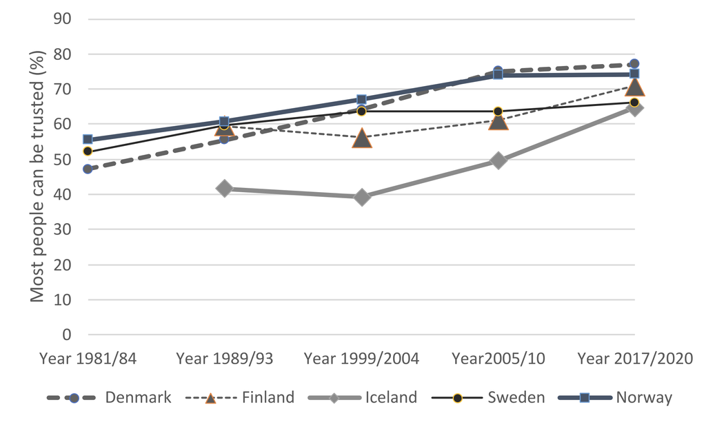

Kilde: European Values Study/World Values survey

## Empiriske funn: hva forklarer sosial tillit?

- Lav sosial tillit
  - nylig opplevd traumatiske opplevelser (Alesina & LaFerrara 2002) ✅
  - tilhørighet til minoritet som historisk er blitt diskriminert (Alesina & LaFerrara 2002, Saltkjel & Malmberg-Heimonen 2014) ✅
  - kvinner (Alesina & LaFerrara 2002) ✅
  - bo i et etnisk mangfoldig område (Alesina & LaFerrara 2002, Uslaner 2002)
  - bo i et område med store inntektsforskjeller (Alesina & LaFerrara 2002, Uslaner 2002)
  - arbeidsledighet (Holmberg & Rothstein, 2020)✅
  - problemer i oppveksten (Saltkjel & Malmberg-Heimonen 2014) ✅
  - opplevd fattigdom (Saltkjel & Malmberg-Heimonen 2014) ✅
  - …
- Høy sosial tillit
  - religiøsitet (Daniels & Von Der Ruhr) ✅
  - engasjement i sivilsamfunnet (Putnam 2007) ✅
  - kvinner (Saltkjel & Malmberg-Heimonen 2014) ✅
  - høy utdanning (Alesina & LaFerrara 2002, Kan & Lai 2021) ✅
  - høy inntekt (Alesina & LaFerrara 2002) ✅
  - god helse (Holmberg & Rothstein 2020) ✅
  - høy alder (Saltkjel & Malmberg-Heimonen 2014) ✅
  - …

# Empirisk tilnærming

- Ved å lese litteraturen på temaet kan vi begynne å danne oss et bilde av forklaringsvariabler for sosial tillit
- st =f(kjønn, alder, sivilstatus, etnisitet, religion, utdanning, sysselsatt, inntekt, bosted, helse ……)
- Her er “st” sosial tillit som er vår endogen variabel (dvs den som vi ønsker å forklare), og de øvrige er forklaringsvariabler (eksogene variabler).
- Vi må velge en form for vår likning, for eksempel lineær:
  $$\begin{split}
  st=\alpha_0+\alpha_1\:kjønn+\alpha_2\:alder+\alpha_3\:sivilstatus+\alpha_4\:etnisitet\\ +\alpha_5\:religion+\alpha_6\:utdanning +\alpha_7\:sysselsatt+\alpha_8\:inntekt + osv
  \end{split}$$
- Her er $\alpha_i$ parametre som vi må estimere med en egnet metode, samt tolke.

## Et empirisk eksempel

- “Social inequalities, social trust and civic participation - the case of Norway” T. Saltkjel & I. Malmberg-Heimonen, European Journal of Social Work, 2013
- “Hovedspørsmålet er hvorvidt og i hvilken grad sosioøkonomiske indikatorer er forbundet med sosial tillit og sivil deltagelse”.
- Data fra ca 2008 (?) N=3190 (før Medborgerpanelet, men en del av de samme spørsmålene)

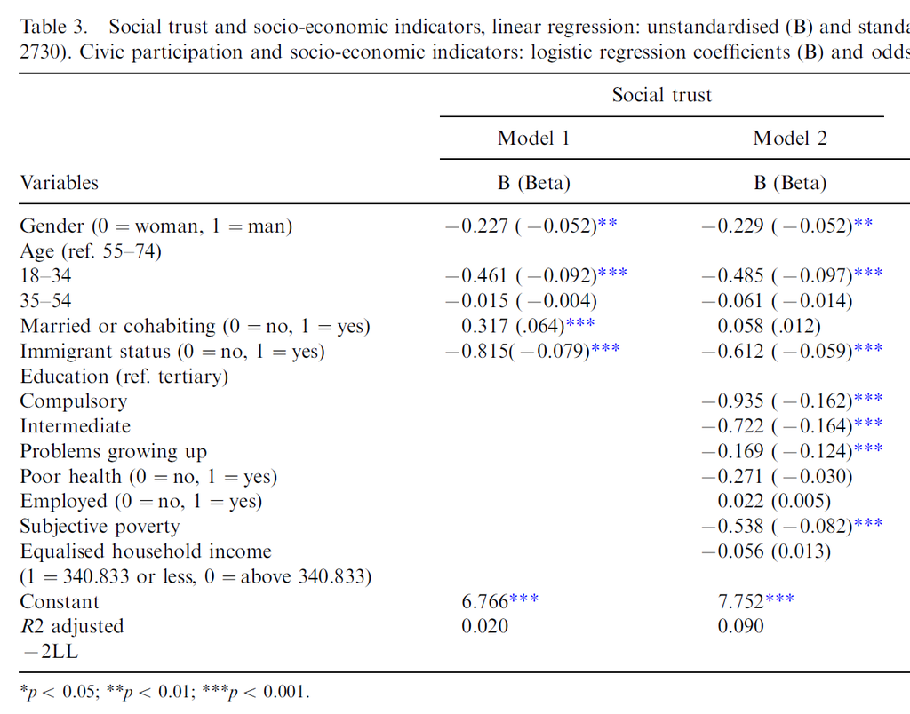

## Medborgerpanelet 2023 (Runde 26)

Tillit r26_pccoo

### r26_pccoo

De fleste mennesker i sin alminnelighet er til å stole på

| Value | Category |
| --- | --- |
| 0 | 0 - Kan ikke være forsiktig nok |
| 1 | 1 |
| 2 | 2 |
| 3 | 3 |
| 4 | 4 |
| 5 | 5 |
| 6 | 6 |
| 7 | 7 |
| 8 | 8 |
| 9 | 9 |
| 10 | 10 - De fleste er til å stole på |
| 97 | Ikke svart* |
| 98 | Ikke spurt* |

*) Missing Value

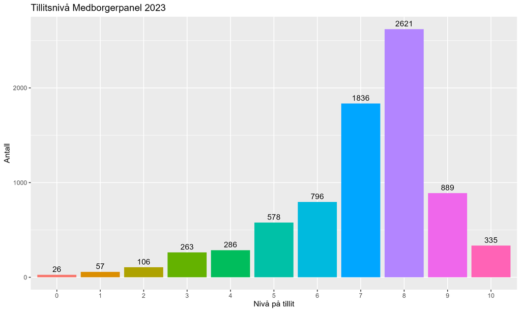

Tillit etter kjønn (r26P1)

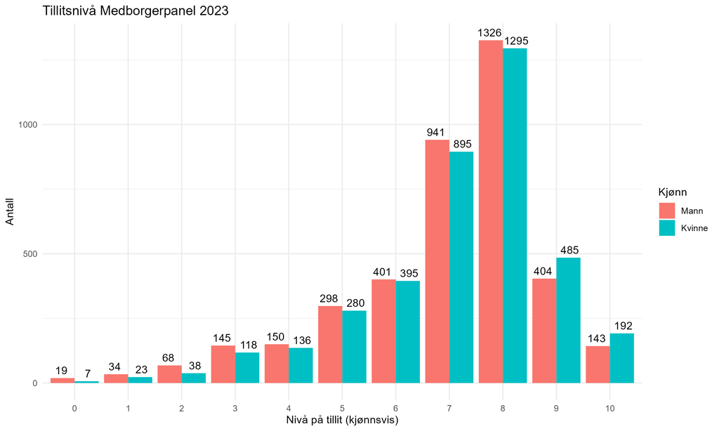

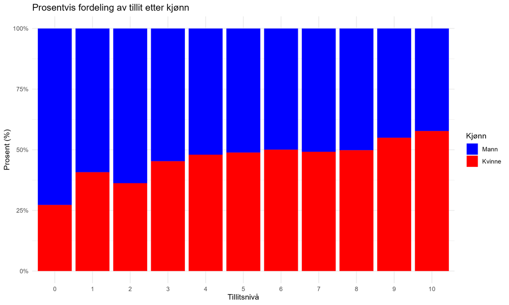

### r26P4_2

Høyeste fullførte utdanning

| Value | Category |
| --- | --- |
| 1 | Ingen fullført utdanning |
| 2 | Grunnskole (Fullført enten første del av obligatorisk utdanning (barneskole), grunnskole, 7-årig folkeskole, framhald |
| 3 | Videregående utdanning - allmennfaglige studieretninger/ studieforberedende utdanningsprogram, ettårig påbygging til |
| 4 | Videregående utdanning - yrkesfaglige studieretninger/utdanningsprogram (VK2, VK3, VG3, fagprøve, svenneprøve) |
| 5 | Vitnemål fra påbygging til videregående utdanning (fagskoleutdanning, teknisk fagskole) |
| 6 | Universitet/høgskole, mindre enn 3 år, men minst 2 år (høgskolekandidat 2- og 2½- årig) |
| 7 | Høgskole - 3-4 årig utdanning (Bachelor-, cand.mag., lærerhøgskole, sykepleierhøgskole, førskolelærer, ingeniør, |
| 8 | Universitet - 3-4 årig utdanning (Bachelor, cand.mag.) |
| 9 | Høgskole - 5-6 årig utdanning (Master, hovedfag) |
| 10 | Universitet - 5-6 årig utdanning (Master, hovedfag) (Lengre profesjonsutdanning (cand.theol., cand.psychol., cand.med., |
| 11 | Forskernivå (Doktorgrad, Ph.d.) |
| 12 | Ingen av disse (vennligst skriv inn): |
| 97 | Ikke svart* |

*) Missing Value

[figure not shown]

Gjennomsnittstillit = 7.06

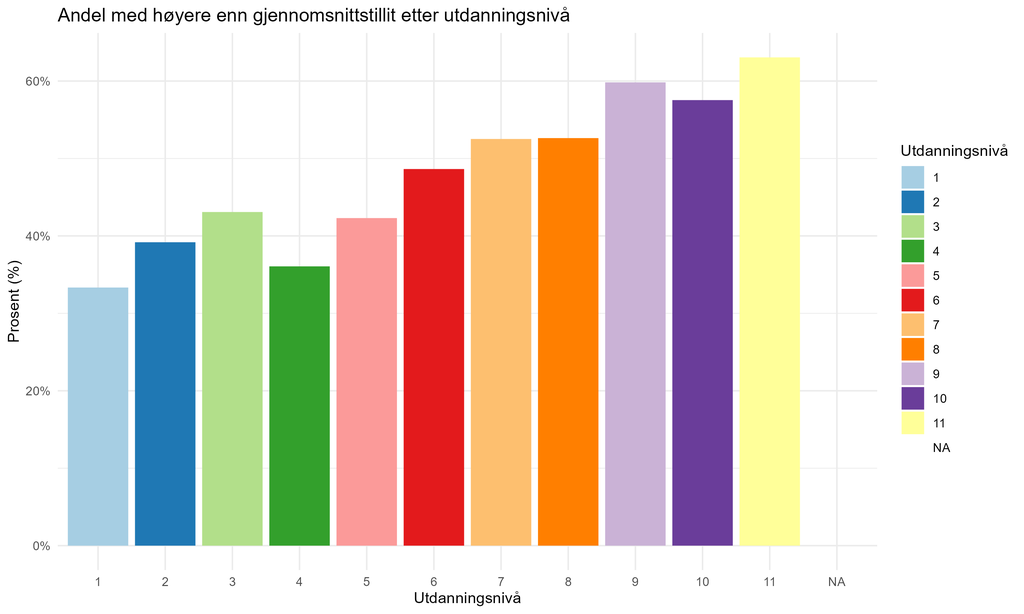

## Referanser

- Alesina, A., & La Ferrara, E. (2002). Who trusts others? *Journal of Public Economics*, 85(2), 207–234.
- Andreasson, U., (2017), *Trust — the Nordic Gold*, Copenhagen: Nordic Council of Ministers.
- Arrow, K. J. (1974). *The limits of organization*. WW Norton & Company.
- Craig, M. A., Rucker, J. M., & Richeson, J. (2018). The pitfalls and promise of increasing racial diversity: Threat, contact, and race relations in the 21st century. *Current Directions in Psychological Science*, 27(3), 188–193.
- Daniels, J. P., & Von Der Ruhr, M. (2010). Trust in others: Does religion matter?. Review of Social Economy, 68(2), 163-186.
- Furlong, D. (1996). The conceptualization of “trust” in economic thought. IDS Working Paper.
- Granovetter, M. (1985). Economic action and social structure: the problem of embeddedness. *American Journal of Sociology*, 91, 481-510.
- Holmberg, S., & Rothstein, B. (2020). Minskar mångkulturella samhällen den sociala tilliten? [Does diverse societies decrease social trust?]. In U. Andersson, A., Carlander, & P. Öhberg (Eds.), *Regntunga skyar* (pp. 27–40). Göteborgs universitet; SOM-institutet.
- Kan, K., & Lai, T. K. (2021). Educated to be trusting? Evidence from Europe. *Economics Letters*, 203, 109867.
- Mahoney, J. T. (2004). *Economic foundations of strategy*. Sage Publications.
- Putnam, R. D. (2007). E pluribus unum: Diversity and community in the twenty-first century, The 2006 Johan Skytte Prize Lecture. *Scandinavian Political Studies*, 30(2), 137–174.
- Saltkjel, T., & Malmberg-Heimonen, I. (2014). Social inequalities, social trust and civic participation—the case of Norway. *European Journal of Social Work*,17(1), 118-134.
- Uslaner, E. M. (2002). *The moral foundations of trust*. Cambridge University Press.

uit-sok-2209-v24.github.io/